# Results

Beata Vekeriotaite

7/2/2022

## Propionylated histones are associated with active promoters and enhancers and overlaps other active histone modifications

First, I looked at where propionylation is located in the genome. To do this, peak enrichment analysis based on genomic feature annotations (i.e., promoter, gene body, enhancer, etc.) and ENCODE candidate cis-regulatory elements was performed. This was done independently for H3K14pr (further referred to as K14pr) and panKpr, which is global histone lysine propionylation, i.e. not corresponding to any particular residue. Duplication rate was higher in K14pr based on the QC data (not shown) than in other modifications, hence, it was decided to remove the duplicate peaks for this analysis. This indicated, however, that deduplication does not have a major effect on the overall trend of K14pr location. Hence, all the further analysis was conducted using deduplicated peak values.

Both K14pr (Fig 1) and panKpr (Fig 3) were identified to be located close to transcription start site - likely in promoters and enhancers. Similarly, when looking at ENCODE candidate cis-regulatory elements, it was clear that propionylation was predominantly taking place at promoter-like sequences (PLS) and proximal enhancer-like sequences (pELS) (Fig 2, Fig 4). Interestingly, locations of both K14pr and panKpr overlapped other active histone modifications, H3K4me1 (K4me in the plot), HK4me3 (K4me3 in the plot), and H3K27ac (K27ac in the plot) (Fig 5).

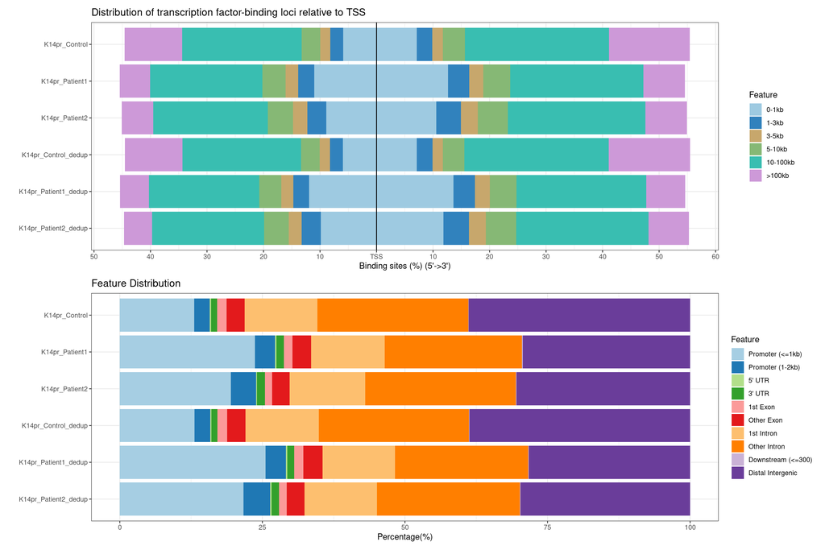

Figure 1. Distribution of H3K14pr in relation to transcription start site (TSS) (top) an in terms of genomic locations (bottom)

```r
peakAnno <- readRDS("~/public/BeataVekeriotaite/Bioinformatics course 2022/Practice/Assignments/materials2022/project/code/CnT_S112_filtPeakAnno.rds")
comb_FE   <- readRDS("~/public/BeataVekeriotaite/Bioinformatics course 2022/Practice/Assignments/materials2022/project/code/CnT_S112_filtPeakFeatureEnrichment.rds")

p1 <- plotDistToTSS(peakAnno[grep("K14pr_", names(peakAnno))])
p2 <- plotAnnoBar(peakAnno[grep("K14pr_", names(peakAnno))])

p1/p2
```

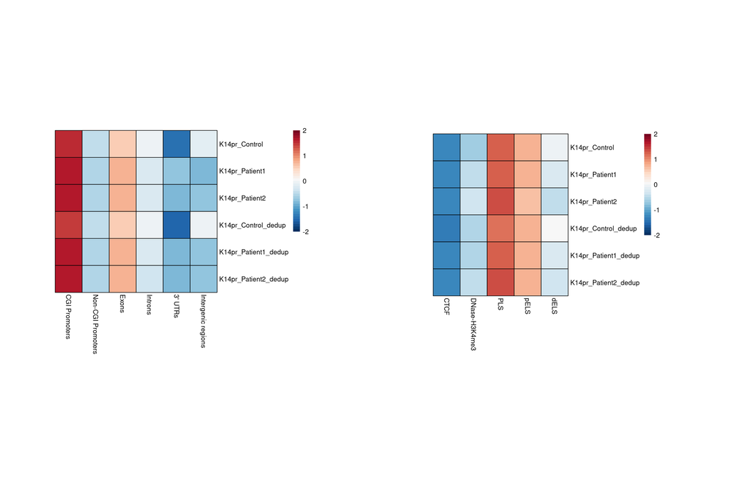

```r
#### Peak fold enrichment

breaksList <- seq(-2, 2, by = 0.1)

genomicFeatures <- c("CGI Promoters","Non-CGI Promoters", "Exons", "Introns", "3' UTRs", "Intergenic regions")
cCREs <- c("CTCF", "DNase-H3K4me3", "PLS","pELS", "dELS")

a1 <- pheatmap::pheatmap(t(comb_FE[genomicFeatures,grep("K14pr_", colnames(comb_FE))]),
                   silent            = T,
                   cutree_rows       = 2,
                   cutree_cols       = 2,
                   scale             = "row",
                   color             = colorRampPalette(rev(brewer.pal(n=11, name="RdBu")))(length(breaksList)),
                   fontsize_row      = 10,
                   fontsize_col      = 10,
                   display_numbers   = FALSE,
                   fontsize_number   = 10,
                   cluster_cols      = FALSE,
                   cluster_rows      = FALSE,
                   cellheight        = 40,
                   cellwidth         = 40,
                   border_color      = 'black',
                   breaks            = breaksList)
# ENCODE cCREs
a2 <- pheatmap::pheatmap(t(comb_FE[cCREs,grep("K14pr_", colnames(comb_FE))]),
                   silent            = T,
                   cutree_rows       = 2,
                   cutree_cols       = 2,
                   scale             = "row",
                   color             = colorRampPalette(rev(brewer.pal(n=11, name="RdBu")))(length(breaksList)),
                   fontsize_row      = 10,
                   fontsize_col      = 10,
                   display_numbers   = FALSE,
                   fontsize_number   = 10,
                   cluster_cols      = FALSE,
                   cluster_rows      = FALSE,
                   cellheight        = 40,
                   cellwidth         = 40,
                   border_color      = 'black',
                   breaks            = breaksList)

plot_grid(a1[[4]],a2[[4]])
```

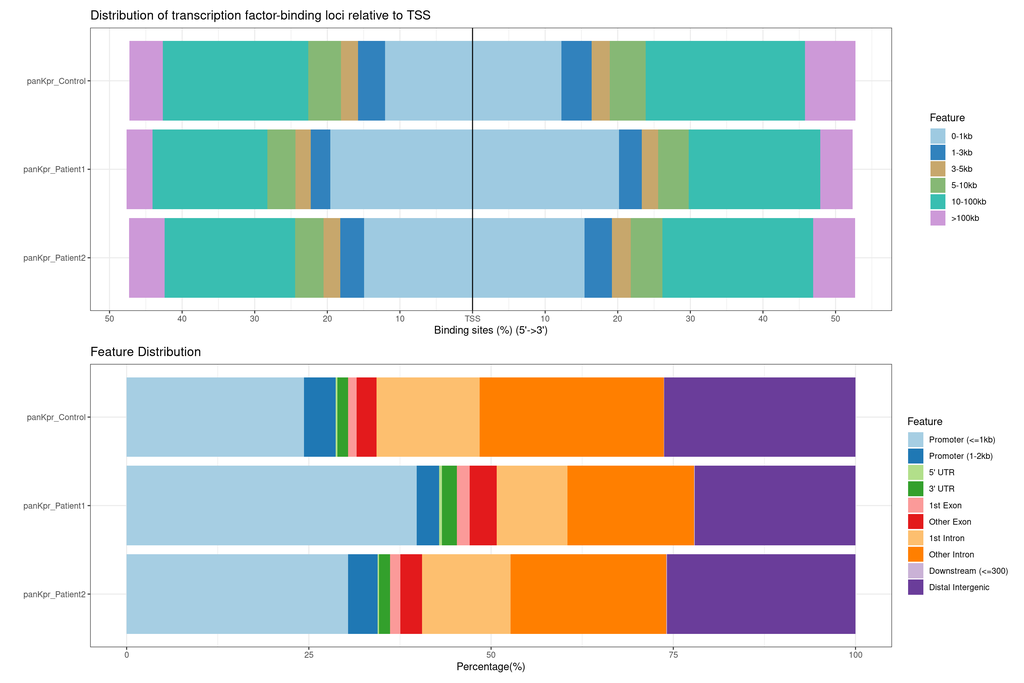

```r
# panKpr

# Peak annotation

c1 <- plotDistToTSS(peakAnno[grep("panKpr_", names(peakAnno))])
c2 <- plotAnnoBar(peakAnno[grep("panKpr_", names(peakAnno))])

c1/c2
```

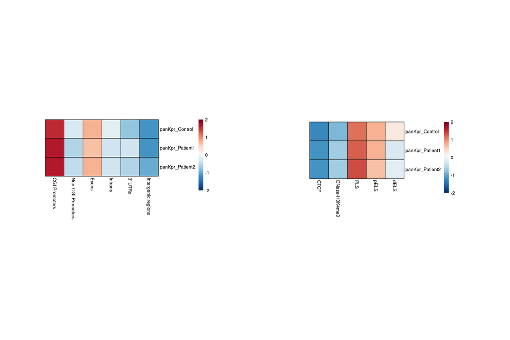

```r
# Peak fold enrichment

breaksList <- seq(-2, 2, by = 0.1)

genomicFeatures <- c("CGI Promoters","Non-CGI Promoters", "Exons", "Introns", "3' UTRs", "Intergenic regions")
cCREs <- c("CTCF", "DNase-H3K4me3", "PLS","pELS", "dELS")

b1 <- pheatmap::pheatmap(t(comb_FE[genomicFeatures,grep("panKpr_", colnames(comb_FE))]),
                   silent            = T,
                   cutree_rows       = 2,
                   cutree_cols       = 2,
                   scale             = "row",
                   color             = colorRampPalette(rev(brewer.pal(n=11, name="RdBu")))(length(breaksList)),
                   fontsize_row      = 10,
                   fontsize_col      = 10,
                   display_numbers   = FALSE,
                   fontsize_number   = 10,
                   cluster_cols      = FALSE,
                   cluster_rows      = FALSE,
                   cellheight        = 40,
                   cellwidth         = 40,
                   border_color      = 'black',
                   breaks            = breaksList)

# ENCODE cCREs
b2 <- pheatmap::pheatmap(t(comb_FE[cCREs,grep("panKpr_", colnames(comb_FE))]),
                   silent            = T,
                   cutree_rows       = 2,
                   cutree_cols       = 2,
                   scale             = "row",
                   color             = colorRampPalette(rev(brewer.pal(n=11, name="RdBu")))(length(breaksList)),
                   fontsize_row      = 10,
                   fontsize_col      = 10,
                   display_numbers   = FALSE,
                   fontsize_number   = 10,
                   cluster_cols      = FALSE,
                   cluster_rows      = FALSE,
                   cellheight        = 40,
                   cellwidth         = 40,
                   border_color      = 'black',
                   breaks            = breaksList)


plot_grid(b1[[4]],b2[[4]])
```

```r
# Reading in the data

CnTlist_ctr <- list(
                K27me3="~/public/BeataVekeriotaite/KISPI/MattNeurons/CnT/bed/S112_01_hsneurons_Control_K27me3_GRCh38_bt2.sorted.dupflag.FDR_0.01.stringent.bed",
                K4me="~/public/BeataVekeriotaite/KISPI/MattNeurons/CnT/bed/S112_02_hsneurons_Control_K4me_GRCh38_bt2.sorted.dupflag.FDR_0.01.stringent.bed",
                K4me3="~/public/BeataVekeriotaite/KISPI/MattNeurons/CnT/bed/S112_03_hsneurons_Control_K4me3_GRCh38_bt2.sorted.dupflag.FDR_0.01.stringent.bed",
                K36me3="~/public/BeataVekeriotaite/KISPI/MattNeurons/CnT/bed/S112_05_hsneurons_Control_K36me3_GRCh38_bt2.sorted.dupflag.FDR_0.01.stringent.bed",
                K9me3="~/public/BeataVekeriotaite/KISPI/MattNeurons/CnT/bed/S112_04_hsneurons_Control_K9me3_GRCh38_bt2.sorted.dupflag.FDR_0.01.stringent.bed",
                K27ac="~/public/BeataVekeriotaite/KISPI/MattNeurons/CnT/bed/S112_06_hsneurons_Control_K27ac_GRCh38_bt2.sorted.dupflag.FDR_0.01.stringent.bed",
                panKpr="~/public/BeataVekeriotaite/KISPI/MattNeurons/CnT/bed/S112_07_hsneurons_Control_panKpr_GRCh38_bt2.sorted.dupflag.FDR_0.01.stringent.bed",
                K14pr="~/public/BeataVekeriotaite/KISPI/MattNeurons/CnT/bed/S112_08_hsneurons_Control_K14pr_GRCh38_bt2.sorted.dupflag.FDR_0.01.stringent.bed")


CnTlist_P1 <- list(
                K27me3="~/public/BeataVekeriotaite/KISPI/MattNeurons/CnT/bed/S112_09_hsneurons_Patient1_K27me3_GRCh38_bt2.sorted.dupflag.FDR_0.01.stringent.bed",
                K4me="~/public/BeataVekeriotaite/KISPI/MattNeurons/CnT/bed/S112_10_hsneurons_Patient1_K4me_GRCh38_bt2.sorted.dupflag.FDR_0.01.stringent.bed",
                K4me3="~/public/BeataVekeriotaite/KISPI/MattNeurons/CnT/bed/S112_11_hsneurons_Patient1_K4me3_GRCh38_bt2.sorted.dupflag.FDR_0.01.stringent.bed",
                K36me3="~/public/BeataVekeriotaite/KISPI/MattNeurons/CnT/bed/S112_13_hsneurons_Patient1_K36me3_GRCh38_bt2.sorted.dupflag.FDR_0.01.stringent.bed",
                K9me3="~/public/BeataVekeriotaite/KISPI/MattNeurons/CnT/bed/S112_12_hsneurons_Patient1_K9me3_GRCh38_bt2.sorted.dupflag.FDR_0.01.stringent.bed",
                K27ac="~/public/BeataVekeriotaite/KISPI/MattNeurons/CnT/bed/S112_14_hsneurons_Patient1_K27ac_GRCh38_bt2.sorted.dupflag.FDR_0.01.stringent.bed",
                panKpr="~/public/BeataVekeriotaite/KISPI/MattNeurons/CnT/bed/S112_15_hsneurons_Patient1_panKpr_GRCh38_bt2.sorted.dupflag.FDR_0.01.stringent.bed",
                K14pr="~/public/BeataVekeriotaite/KISPI/MattNeurons/CnT/bed/S112_16_hsneurons_Patient1_K14pr_GRCh38_bt2.sorted.dupflag.FDR_0.01.stringent.bed")


CnTlist_P2 <- list(
                K27me3="~/public/BeataVekeriotaite/KISPI/MattNeurons/CnT/bed/S112_17_hsneurons_Patient2_K27me3_GRCh38_bt2.sorted.dupflag.FDR_0.01.stringent.bed",
                K4me="~/public/BeataVekeriotaite/KISPI/MattNeurons/CnT/bed/S112_18_hsneurons_Patient2_K4me_GRCh38_bt2.sorted.dupflag.FDR_0.01.stringent.bed",
                K4me3="~/public/BeataVekeriotaite/KISPI/MattNeurons/CnT/bed/S112_19_hsneurons_Patient2_K4me3_GRCh38_bt2.sorted.dupflag.FDR_0.01.stringent.bed",
                K36me3="~/public/BeataVekeriotaite/KISPI/MattNeurons/CnT/bed/S112_21_hsneurons_Patient2_K36me3_GRCh38_bt2.sorted.dupflag.FDR_0.01.stringent.bed",
                K9me3="~/public/BeataVekeriotaite/KISPI/MattNeurons/CnT/bed/S112_20_hsneurons_Patient2_K9me3_GRCh38_bt2.sorted.dupflag.FDR_0.01.stringent.bed",
                K27ac="~/public/BeataVekeriotaite/KISPI/MattNeurons/CnT/bed/S112_22_hsneurons_Patient2_K27ac_GRCh38_bt2.sorted.dupflag.FDR_0.01.stringent.bed",
                panKpr="~/public/BeataVekeriotaite/KISPI/MattNeurons/CnT/bed/S112_23_hsneurons_Patient2_panKpr_GRCh38_bt2.sorted.dupflag.FDR_0.01.stringent.bed",
                K14pr="~/public/BeataVekeriotaite/KISPI/MattNeurons/CnT/bed/S112_24_hsneurons_Patient2_K14pr_GRCh38_bt2.sorted.dupflag.FDR_0.01.stringent.bed")
```

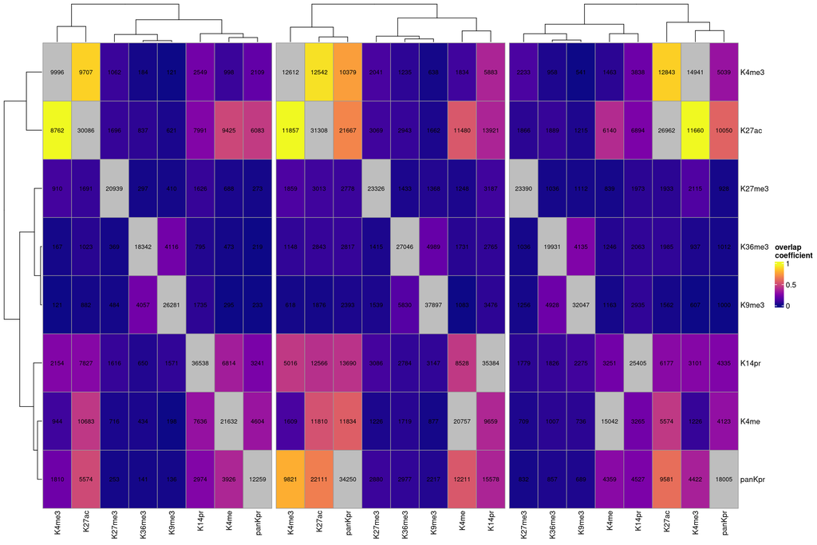

Figure 5. Overlaps among histone modifications in control (left), patient 1 (middle) an patient 2 (right)

```r
# Overlaps

myimport <- function(x){
  x <- read.delim(x, header=FALSE)
  GRanges(x[,1], IRanges(x[,2], x[,3]))
}

peaks <- lapply(CnTlist_ctr, myimport)

peaks_p1 <- lapply(CnTlist_P1, myimport)

peaks_p2 <- lapply(CnTlist_P2, myimport)


# Histone modification overlaps in control
G1 <- regionOverlaps(peaks)

# Histone modification overlaps in patient 1
G2 <- regionOverlaps(peaks_p1)

# Histone modification overlaps in patient2
G3 <- regionOverlaps(peaks_p2)


G1+G2+G3
```